[interactive chart not shown]

# Equation

[interactive chart not shown]

## Dataset

令 $X_1,X_2,\cdots,X_n$ 服从参数为 $p$ 的伯努利分布，令 $n = 100, \epsilon = 0.2$，由**切比雪夫不等式**可得

$$ \mathbb{P}\left(\left|\bar{X}_{n}-p\right|>\varepsilon\right) \leqslant \frac{\mathbb{V}\left(\bar{X}_{n}\right)}{\varepsilon^{2}}=\frac{p(1-p)}{n \varepsilon^{2}} \leqslant \frac{1}{4 n \varepsilon^{2}}= 0.0625 $$

而若是使用 **Chernoff bound**，则

$$ \mathbb{P}\left(\left|\bar{X}_{n}-p\right|>\varepsilon\right) \leqslant 2 \mathrm{e}^{-2 n \varepsilon^{2}} = 0.00067 $$

> Ref: [All of Statistics：统计学完全教程](https://link.springer.com/book/10.1007/978-0-387-21736-9)

```python
import numpy as np
def generate_prob(n = 100, p = 0.8, eps = 0.2):
    """
    @param: n (int): 子样个数
    @param: p (float): 伯努利分布成功概率
    @param: eps (float): 容忍偏差, bias
    """
    sample = [np.abs(np.random.binomial(n=1, p=p, size=n).mean() - p) for i in range(10000)] # 10000 仿真次数
    Prob = (np.array(sample) >= eps).mean()
    return Prob

generate_prob(n = 100, p = 0.8, eps = 0.2)
```

```
0.0
```

## Plots

```python
import matplotlib.pyplot as plt
import math
%matplotlib inline
```

### 动态改变 $\epsilon$

```python
epsilon = np.linspace(start=0.02, stop=0.25, num=200)
various_eps = [generate_prob(n = 100, p = 0.8, eps = eps) for eps in epsilon] # fix n=100 and p = 0.8
upper_Chebyshev = [1.0 / (4 * 100 * eps ** 2) for eps in epsilon]
upper_Chernoff = [2 * math.exp(-2 * 100 * eps ** 2) for eps in epsilon]
```

```python
plt.semilogy(epsilon, various_eps, 'r-',label="Simulation")
plt.semilogy(epsilon, upper_Chebyshev, 'g-',label="Chebyshev upper bound")
plt.semilogy(epsilon, upper_Chernoff, 'b-',label="Chernoff upper bound")
plt.legend()
plt.xlabel("$\epsilon$")
plt.ylabel("$Prob$")
plt.title("$n = 100, p = 0.8$")
plt.savefig("./img/dynamic_eps.png", dpi=200)
plt.show()
```

[output not shown]

### 动态改变 $n$

```python
n_range = list(range(10,201))
various_n = [generate_prob(n = n, p = 0.8, eps = 0.14) for n in n_range] # fix eps = 0.05 and p = 0.8
upper_Chebyshev = [1.0 / (4 * n *  0.14 ** 2) for n in n_range]
upper_Chernoff = [2 * math.exp(-2 * n *  0.14 ** 2) for n in n_range]
```

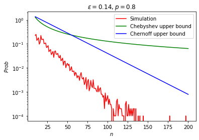

```python
plt.semilogy(n_range, various_n, 'r-',label="Simulation")
plt.semilogy(n_range, upper_Chebyshev, 'g-',label="Chebyshev upper bound")
plt.semilogy(n_range, upper_Chernoff, 'b-',label="Chernoff upper bound")
plt.legend()
plt.xlabel("$n$")
plt.ylabel("$Prob$")
plt.title("$\epsilon = 0.14, p = 0.8$")
plt.savefig("./img/dynamic_n.png", dpi=200)
plt.show()
```

### 动态改变 $p$

值的注意的是 Chernoff upper bound 与 $p$ 无关，但是 Chebyshev upper bound 与 $p$ 有关

```python
p_range = np.linspace(start=0.01, stop=0.99, num=200)
various_p = [generate_prob(n = 100, p = p, eps = 0.14) for p in p_range] # fix n=100 and eps = 0.14
upper_Chebyshev = [p * (1 - p) / (100 * 0.14 ** 2) for p in p_range]
upper_Chernoff = [2 * math.exp(-2 * 100 * 0.14 ** 2) for p in p_range]
```

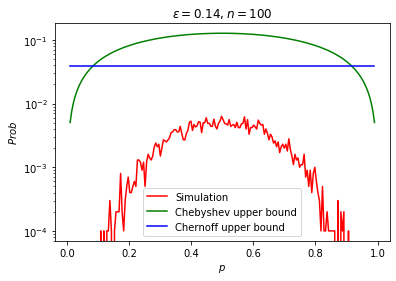

```python
plt.semilogy(p_range, various_p, 'r-',label="Simulation")
plt.semilogy(p_range, upper_Chebyshev, 'g-',label="Chebyshev upper bound")
plt.semilogy(p_range, upper_Chernoff, 'b-',label="Chernoff upper bound")
plt.legend()
plt.xlabel("$p$")
plt.ylabel("$Prob$")
plt.title("$\epsilon = 0.14, n = 100$")
plt.savefig("./img/dynamic_p.png", dpi=200)
plt.show()
```

> 这图，，，似乎没啥用

# 阅读分享：机器学习理论的回顾与展望——北大王立威教授

2019-10-17

这篇文章是王立威教授在中国人工智能学会 [AIDL](https://aidl.caai.cn/2) 第二期**人工智能前沿讲习班：机器学习前沿**所作报告， slides 可以关注 [AIDL](https://aidl.caai.cn/2) 公众号后台回复关键字获取。演讲内容可以阅读 [CSDN **转载**整理版](https://blog.csdn.net/xiangz_csdn/article/details/60865980)。

当初看到这篇文章是很激动的，现在回想一开始吸引我走进 ML 这个坑的就是像 VC theory 和 Margin theory 这种有**很漂亮数学理论**的传统机器学习理论与算法。就像王教授在报告最后提出的：**这两个理论确实很难用来解释深度学习**。但是学习这些基础显然还是很必要的，因此在这里 mark 一下。最后是一些个人的理解和想法，并尝试从仿真的角度直观理解其中提到的几个不等式。

[figure not shown]

more >>

- 统计
- machine learning

# 新的起点： 每个人都有一个觉醒的过程，但是这个过程的早晚会决定一生

2019-10-05

## 焦虑的开始

保研正式结束了，以后可以去燕园培养人文情怀了。六月拿到北大信科优秀营员后，老师安排了我和师兄做科研，方向我也很喜欢。

> 当时得知拿到优营后，便在酒店激动的放飞了自我！

但是整个暑假和开学返校后，内心一直很**焦虑**

- 这真的是最优的选择吗？（周围有直博和出国的大佬）
- 我适合科研还是工作呢？
- 我真的适合 ML 方向吗？

现在想想，连这些都没想通，怎么可能不焦虑！这是必然的，因为我一直以来都**想的不够多**。保研群一群友给我画了个饼：出国镶金回来找教职。不过说不定硕士毕业就直接工作了，who knows。[暗时间](https://book.douban.com/subject/6709809/) 中说：**善于利用思维时间的人，可以无形中比别人多出很多时间，从而实际意义上能比别人多活很多年**。

more >>

- -随笔

# 远程服务器上使用 jupyter + matplotlib 绘制动态图

2019-09-13

目前许多深度学习（炼丹）的服务器大多是远程 Linux 服务器，从而没有图形化界面。动态可视化训练过程有时候可能比仅仅 `print` 中间输出更有效。

针对 `pytorch` 也有对应的 [TensorboardX](https://github.com/lanpa/tensorboardX)，但是更多时候可能想**边训练边查看某些特定指标**（如 Loss, Accuracy）的变化情况。这时通过 matplotlib 动态更新图层便好了。为了看到图形化界面，首先需要在服务器上配置 Jupyter，这个网上教程很多，就不赘述了。

more >>

- python
- machine learning

# 浅谈连续函数

2019-06-28

数学分析的学习过程中上来便是极限，连续的概念，而课本中的连续概念却恰恰是用极限定义的。如果细究数学史的话，连续概念是要先于极限的概念提出的。

以下内容旨在粗略介绍我眼中连续概念的前世今生。

# 闭区间上连续函数的性质

为了先直观**凸显**连续函数的威力，我们从一个例题开始。

设实值函数 $f(x)$ 在 $[0,n]$（$n$ 为自然数，$n\ge 2$）上连续，$f(0) = f(n)$，证明存在 $\xi,\xi+1\in[0,n]$ ，使得 $f(\xi) = f(\xi+1)$ 。

题目说的就是下面这个图的意思：

[figure not shown]

more >>

- 数学

tag:

[output not shown]